# INFO550-HW2

Zoey Zuo

9/21/2021

Start writing an R Markdown script for your project. The script can output whatever format you would like. For now, make sure that your script:

##does some sort of data cleaning;

```r
dataset<-mtcars
#grosspower=mpg+wt+am
#am is a factor
dataset$am<-factor(dataset$am)
head(dataset)
```

```
##                    mpg cyl disp  hp drat    wt  qsec vs am gear carb
## Mazda RX4         21.0   6  160 110 3.90 2.620 16.46  0  1    4    4
## Mazda RX4 Wag     21.0   6  160 110 3.90 2.875 17.02  0  1    4    4
## Datsun 710        22.8   4  108  93 3.85 2.320 18.61  1  1    4    1
## Hornet 4 Drive    21.4   6  258 110 3.08 3.215 19.44  1  0    3    1
## Hornet Sportabout 18.7   8  360 175 3.15 3.440 17.02  0  0    3    2
## Valiant           18.1   6  225 105 2.76 3.460 20.22  1  0    3    1
```

```r
#select the variables we need
library(dplyr)
(dataset1<-dataset%>%select(1,4,6,9))
```

```
##                      mpg  hp    wt am
## Mazda RX4           21.0 110 2.620  1
## Mazda RX4 Wag       21.0 110 2.875  1
## Datsun 710          22.8  93 2.320  1
## Hornet 4 Drive      21.4 110 3.215  0
## Hornet Sportabout   18.7 175 3.440  0
## Valiant             18.1 105 3.460  0
## Duster 360          14.3 245 3.570  0
## Merc 240D           24.4  62 3.190  0
## Merc 230            22.8  95 3.150  0
## Merc 280            19.2 123 3.440  0
## Merc 280C           17.8 123 3.440  0
## Merc 450SE          16.4 180 4.070  0
## Merc 450SL          17.3 180 3.730  0
## Merc 450SLC         15.2 180 3.780  0
## Cadillac Fleetwood  10.4 205 5.250  0
## Lincoln Continental 10.4 215 5.424  0
## Chrysler Imperial   14.7 230 5.345  0
## Fiat 128            32.4  66 2.200  1
## Honda Civic         30.4  52 1.615  1
## Toyota Corolla      33.9  65 1.835  1
## Toyota Corona       21.5  97 2.465  0
## Dodge Challenger    15.5 150 3.520  0
## AMC Javelin         15.2 150 3.435  0
## Camaro Z28          13.3 245 3.840  0
## Pontiac Firebird    19.2 175 3.845  0
## Fiat X1-9           27.3  66 1.935  1
## Porsche 914-2       26.0  91 2.140  1
## Lotus Europa        30.4 113 1.513  1
## Ford Pantera L      15.8 264 3.170  1
## Ferrari Dino        19.7 175 2.770  1
## Maserati Bora       15.0 335 3.570  1
## Volvo 142E          21.4 109 2.780  1
```

##creates a nice looking table OR a figure (eventually, we’ll need both);

```r
head(dataset1)
```

```
##                    mpg  hp    wt am
## Mazda RX4         21.0 110 2.620  1
## Mazda RX4 Wag     21.0 110 2.875  1
## Datsun 710        22.8  93 2.320  1
## Hornet 4 Drive    21.4 110 3.215  0
## Hornet Sportabout 18.7 175 3.440  0
## Valiant           18.1 105 3.460  0
```

```r
fit<-lm(hp~mpg+wt+am,data=dataset1)
summary(fit)
```

```
##
## Call:
## lm(formula = hp ~ mpg + wt + am, data = dataset1)
##
## Residuals:
##     Min      1Q  Median      3Q     Max
## -56.017 -25.982  -2.144  24.687 101.676
##
## Coefficients:
##             Estimate Std. Error t value Pr(>|t|)
## (Intercept)  262.191     98.235   2.669 0.012514 *
## mpg           -9.398      2.409  -3.902 0.000546 ***
## wt            15.713     16.454   0.955 0.347787
## am1           56.005     20.048   2.794 0.009298 **
## ---
## Signif. codes:  0 '***' 0.001 '**' 0.01 '*' 0.05 '.' 0.1 ' ' 1
##
## Residual standard error: 40.18 on 28 degrees of freedom
## Multiple R-squared:  0.6898, Adjusted R-squared:  0.6565
## F-statistic: 20.75 on 3 and 28 DF,  p-value: 2.793e-07
```

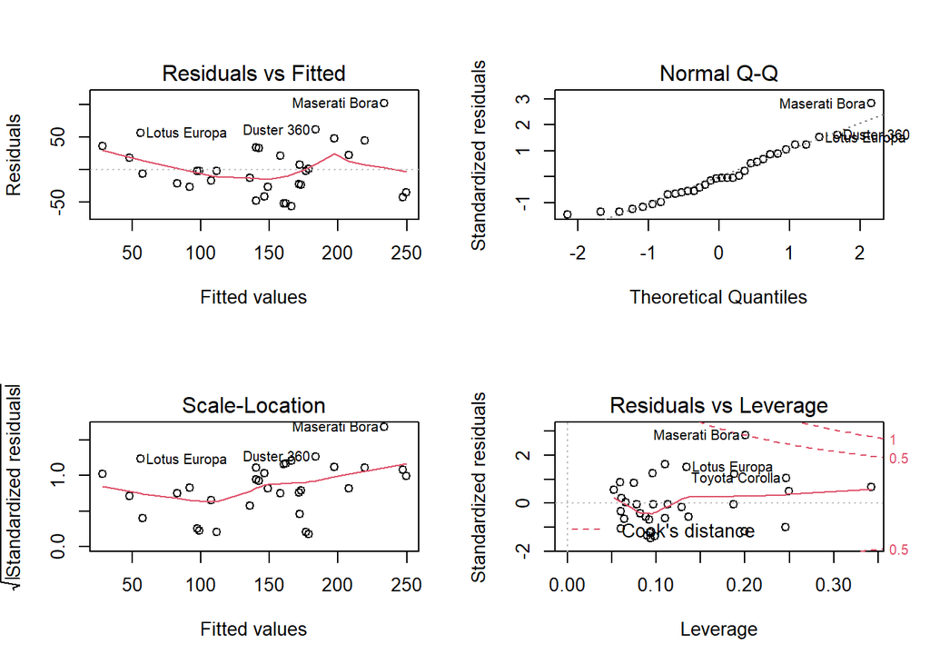

```r
par(mfrow=c(2,2))
plot(fit)
```

##includes plain text description of the analysis and/or results. For this project, the goal is to study whether the Gross horsepower is associate with the Miles/(US) gallon, Weight (1000 lbs), and Transmission (0 = automatic, 1 = manual). Or in other words, whether there is a significant overall regression of Gross horsepower on (Miles/(US) gallon, Weight (1000 lbs), Transmission (0 = automatic, 1 = manual)). Data is an import from the R base, it was extracted from the 1974 Motor Trend US magazine, and comprises fuel consumption and 10 aspects of automobile design and performance for 32 automobiles (1973–74 models). But we will only select four variables for the analysis: Gross horsepower, Miles/(US) gallon, Weight (1000 lbs), and Transmission (0 = automatic, 1 = manual) This is the mathematical expression: $GrossPower_{i}=\beta_0+\beta_1 Miles/(US) gallon_{i1} +\beta_2 Weight (1000 lbs)_{i2}+\beta_3Transmission (0 = automatic, 1 = manual)_{i3}+\epsilon_i$ where i = 1,…,n The Null hypothesis is: $H_0:\beta_1=\beta_2=\beta_3=0$ vs. The alternative hypothesis is :At least one of these $\beta$ coefficints $\neq0$. Based on the informations from the $summary()$ function, since $p-value: 2.793e-07 < \alpha=0.05$, we are able to reject the null hypothesis and accept the alternative hypothesis.